# 不確実性下の人間行動第5講

後藤 晶

# 大きな病院と小さな病院(Tversky and Kahneman, 1974)

ある町に2つの病院があります．大きい方の病院では毎日約45人の赤ちゃんが生まれ，小さい方の病院では毎日約15人の赤ちゃんが生まれる．すべての赤ちゃんのうち男の子の割合は約50%です．しかし，正確な割合は日々変動します．時には50%より高い日もあり，低い日もあります．1年間にそれぞれの病院で生まれた赤ちゃんのうち男の子の割合が60%を超える日を記録しました．どちらの病院の方がそのような日を多く記録したと思いますか？

- 大きな病院
- 小さな病院
- 同じくらい

## 手続き

- 男性か女性のいずれかが生まれる確率過程：
- 2項分布
- 1日に大きな病院では45人，小さな病院では15人生まれることを仮定する．
- 100000日分のデータをシミュレーションする．
- 男性が生まれる確率が60%以上だとすると，大きな病院では`27`人以上，小さな病院では`9`以上が生まれることが条件に合致する．
- さらに，1-100までのデータを時系列でプロットする．

## 大きな病院：

- 男性の生まれた確率が60%以上=`27`人以上生まれた場合．

```r
roll <- function(){
　　SEX <- 0:1
    # 生まれた子どもが男性か女性か．女性を0，男性を1とする．
　　baby <- sample(x = SEX, size = 45 , replace = TRUE)
　　# baby：1日に45人の子どもが生まれることを仮定する．
　　sum(baby)
}
roll()
```

```
## [1] 21
```

```r
rolls <- replicate(100000, roll())


data<-as.data.frame(rolls)

result <- explore(
  data,
  vars = "rolls",
  fun = c("n_obs", "mean", "median", "min", "max", "sd"),
  nr = 1
)
summary(result)
```

```
## Explore
## Data        : data
## Functions   : n_obs, mean, median, min, max, sd
## Top         : Function
##
##  variable   n_obs   mean median min max    sd
##     rolls 100,000 22.487     22   7  36 3.345
```

45人のうちの60%は`27`人なので，`27`人以上と未満に分ける．

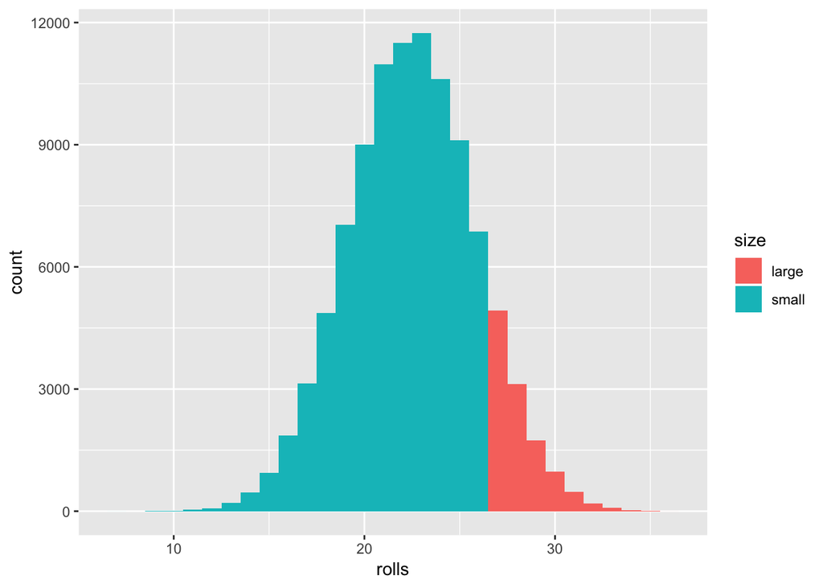

```r
screening<-45*0.6

data %>%
  mutate(size=if_else(rolls >= screening, "large", "small")) ->data


p <- ggplot(data, aes(x=rolls, fill = size)) +
  geom_histogram(binwidth = 1, position = "identity")
p
```

### 頻度

```r
pander(table(data$rolls))
```

Table continues below

| 7 | 9 | 10 | 11 | 12 | 13 | 14 | 15 | 16 | 17 | 18 | 19 | 20 |
| --- | --- | --- | --- | --- | --- | --- | --- | --- | --- | --- | --- | --- |
| 1 | 4 | 10 | 37 | 73 | 204 | 465 | 941 | 1865 | 3134 | 4867 | 7035 | 9009 |

Table continues below

| 21 | 22 | 23 | 24 | 25 | 26 | 27 | 28 | 29 | 30 | 31 |
| --- | --- | --- | --- | --- | --- | --- | --- | --- | --- | --- |
| 10977 | 11501 | 11747 | 10609 | 9109 | 6873 | 4921 | 3119 | 1741 | 965 | 474 |

| 32 | 33 | 34 | 35 | 36 |
| --- | --- | --- | --- | --- |
| 191 | 89 | 30 | 8 | 1 |

### 平均値と標準偏差

```r
mean(rolls) # 平均値
```

```
## [1] 22.48748
```

```r
sd(rolls) # 標準偏差
```

```
## [1] 3.34528
```

### 60%以上が男性である確率

```r
larges<-sum(data$size=="large")
smalls<-sum(data$size=="small")

larges/length(data$rolls)
```

```
## [1] 0.11539
```

### シミュレーションの時系列グラフ

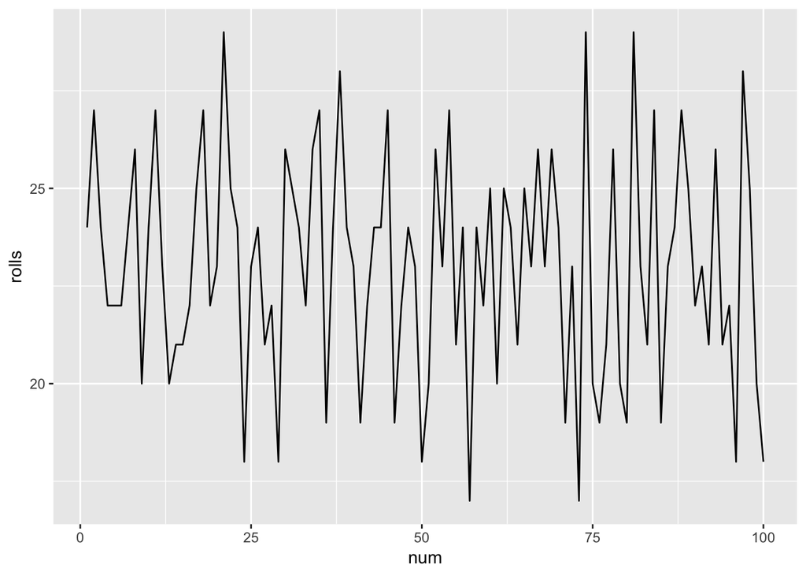

```r
data %>%
  mutate(num = row_number()) %>%
  filter(num <= 100) %>%
  ggplot(aes(x=num, y =rolls)) + geom_line()
```

## 小さな病院：

- 男性の生まれた確率が60%以上=`9`人以上生まれた場合．

```r
roll <- function(){
　　SEX <- 0:1
　　baby <- sample(x = SEX, size = 15 , replace = TRUE)
　　sum(baby)
}
roll()
```

```
## [1] 8
```

```r
rolls <- replicate(100000, roll())


data<-as.data.frame(rolls)

result <- explore(
  data,
  vars = "rolls",
  fun = c("n_obs", "mean", "median", "min", "max", "sd"),
  nr = 1
)
summary(result)
```

```
## Explore
## Data        : data
## Functions   : n_obs, mean, median, min, max, sd
## Top         : Function
##
##  variable   n_obs  mean median min max    sd
##     rolls 100,000 7.502      8   0  15 1.942
```

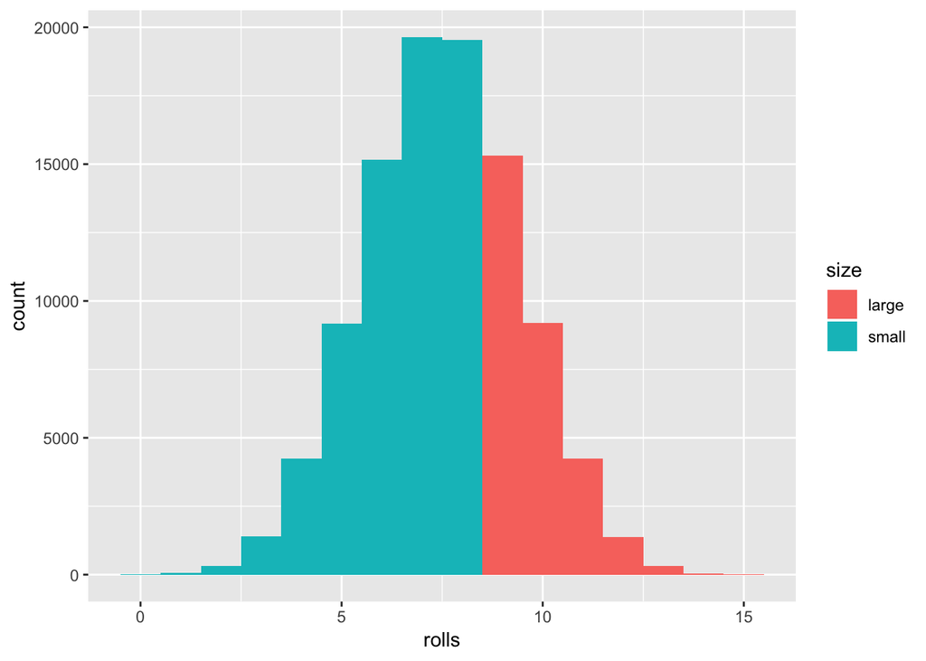

```r
screening<-15*0.6

data %>%
  mutate(size=if_else(rolls >= screening, "large", "small")) ->data


p <- ggplot(data, aes(x=rolls, fill = size)) +
  geom_histogram(binwidth = 1, position = "identity")
p
```

### 頻度

```r
pander(table(data$rolls))
```

Table continues below

| 0 | 1 | 2 | 3 | 4 | 5 | 6 | 7 | 8 | 9 | 10 |
| --- | --- | --- | --- | --- | --- | --- | --- | --- | --- | --- |
| 5 | 55 | 310 | 1387 | 4241 | 9169 | 15158 | 19647 | 19532 | 15305 | 9195 |

| 11 | 12 | 13 | 14 | 15 |
| --- | --- | --- | --- | --- |
| 4242 | 1372 | 329 | 47 | 6 |

### 平均値と標準偏差

```r
mean(rolls) # 平均値
```

```
## [1] 7.50224
```

```r
sd(rolls) # 標準偏差
```

```
## [1] 1.942059
```

### 60%以上が男性である確率

```r
larges<-sum(data$size=="large")
smalls<-sum(data$size=="small")

larges/length(data$rolls)
```

```
## [1] 0.30496
```

### シミュレーションの時系列グラフ

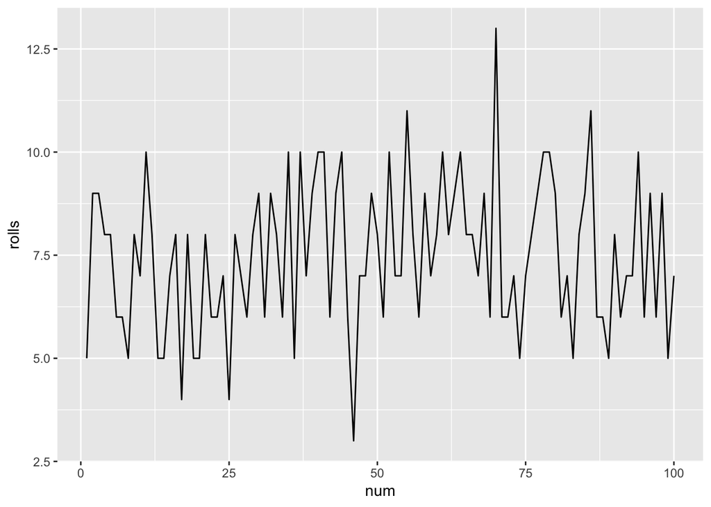

```r
data %>%
  mutate(num = row_number()) %>%
  filter(num <= 100) %>%
  ggplot(aes(x=num, y =rolls)) + geom_line()
```

# 参考：病院で生まれる人数の変化についても分析に入れた場合

## 大きな病院：

- 男性の生まれた確率が60%以上=`27`人以上生まれた場合．

```r
roll <- function(){
　　SEX <- 0:1
    # 生まれた子どもが男性か女性か．女性を0，男性を1とする．
　　baby <- sample(x = SEX, size = round(rnorm(1, mean=45, sd=5)) , replace = TRUE)
　　# baby：1日に45人の子どもが生まれることを仮定する．
　　sum(baby)
}
roll()
```

```
## [1] 22
```

```r
rolls <- replicate(100000, roll())


data<-as.data.frame(rolls)

result <- explore(
  data,
  vars = "rolls",
  fun = c("n_obs", "mean", "median", "min", "max", "sd"),
  nr = 1
)
summary(result)
```

```
## Explore
## Data        : data
## Functions   : n_obs, mean, median, min, max, sd
## Top         : Function
##
##  variable   n_obs   mean median min max    sd
##     rolls 100,000 22.495     22   8  42 4.192
```

45人のうちの60%は`27`人なので，`27`人以上と未満に分ける．

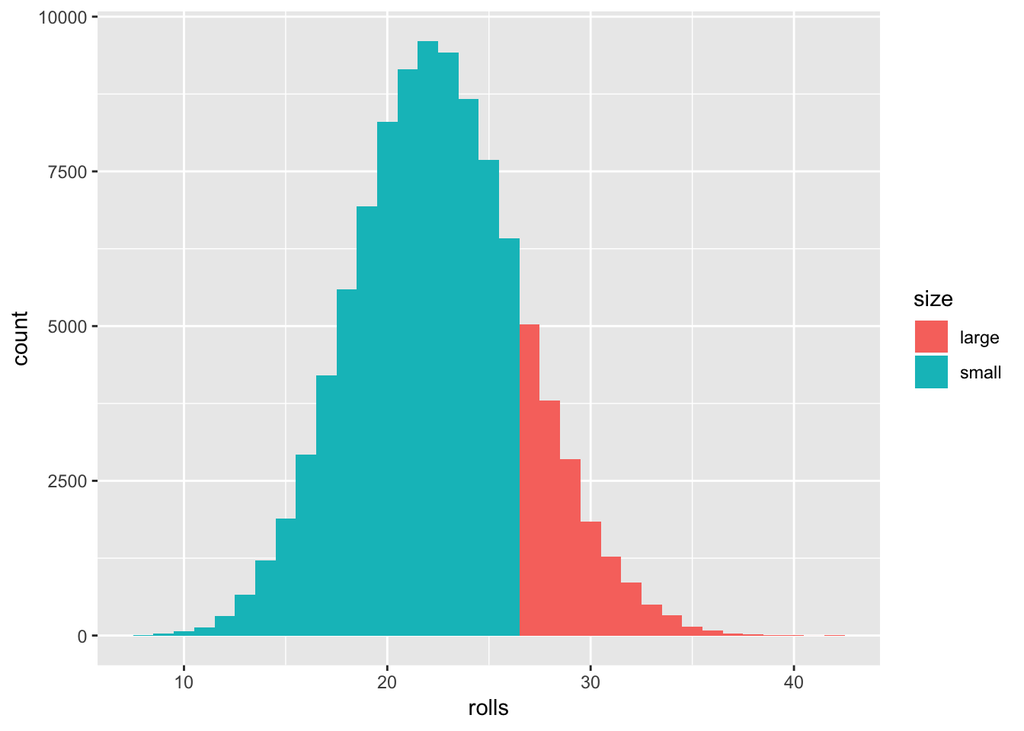

```r
screening<-45*0.6

data %>%
  mutate(size=if_else(rolls >= screening, "large", "small")) ->data


p <- ggplot(data, aes(x=rolls, fill = size)) +
  geom_histogram(binwidth = 1, position = "identity")
p
```

### 頻度

```r
pander(table(data$rolls))
```

Table continues below

| 8 | 9 | 10 | 11 | 12 | 13 | 14 | 15 | 16 | 17 | 18 | 19 | 20 |
| --- | --- | --- | --- | --- | --- | --- | --- | --- | --- | --- | --- | --- |
| 4 | 28 | 75 | 125 | 315 | 658 | 1217 | 1891 | 2919 | 4208 | 5598 | 6929 | 8302 |

Table continues below

| 21 | 22 | 23 | 24 | 25 | 26 | 27 | 28 | 29 | 30 | 31 |
| --- | --- | --- | --- | --- | --- | --- | --- | --- | --- | --- |
| 9152 | 9609 | 9422 | 8668 | 7686 | 6420 | 5029 | 3799 | 2848 | 1844 | 1279 |

| 32 | 33 | 34 | 35 | 36 | 37 | 38 | 39 | 40 | 41 | 42 |
| --- | --- | --- | --- | --- | --- | --- | --- | --- | --- | --- |
| 855 | 505 | 324 | 138 | 80 | 37 | 20 | 8 | 5 | 1 | 2 |

### 平均値と標準偏差

```r
mean(rolls) # 平均値
```

```
## [1] 22.49472
```

```r
sd(rolls) # 標準偏差
```

```
## [1] 4.192072
```

### 60%以上が男性である確率

```r
larges<-sum(data$size=="large")
smalls<-sum(data$size=="small")

larges/length(data$rolls)
```

```
## [1] 0.16774
```

### シミュレーションの時系列グラフ

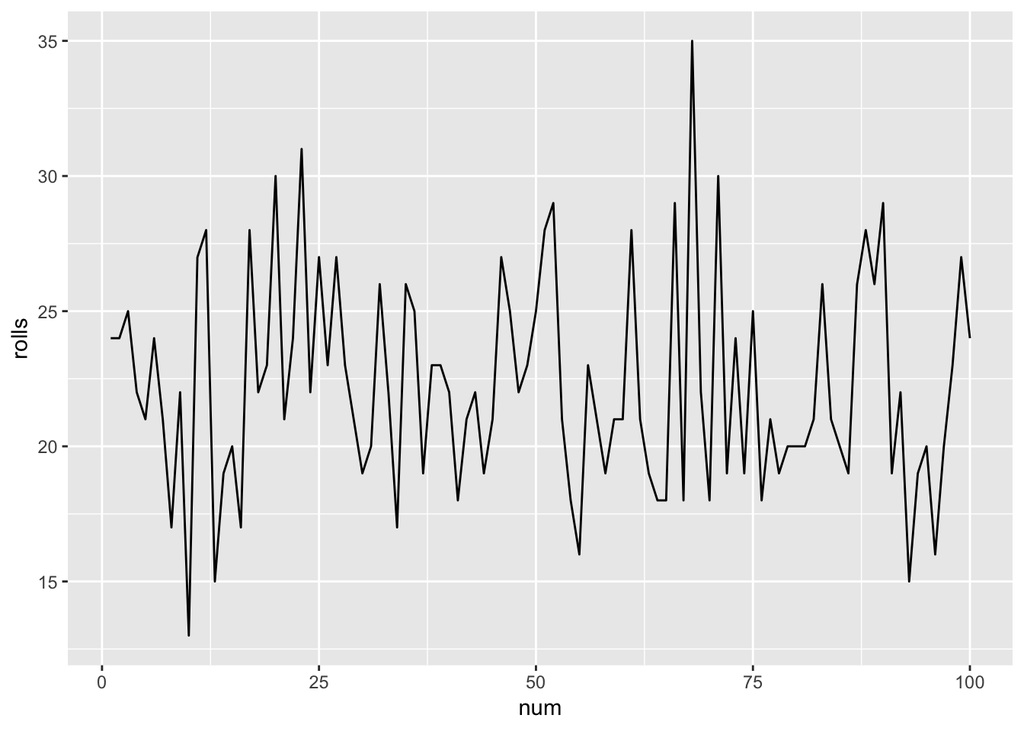

```r
data %>%
  mutate(num = row_number()) %>%
  filter(num <= 100) %>%
  ggplot(aes(x=num, y =rolls)) + geom_line()
```

## 小さな病院：

- 男性の生まれた確率が60%以上=`9`人以上生まれた場合．

```r
roll <- function(){
　　SEX <- 0:1
    # 生まれた子どもが男性か女性か．女性を0，男性を1とする．
　　baby <- sample(x = SEX, size = round(rnorm(1, mean=15, sd=3)), replace = TRUE)
　　# baby：1日に45人の子どもが生まれることを仮定する．
　　sum(baby)
}
roll()
```

```
## [1] 4
```

```r
rolls <- replicate(100000, roll())


data<-as.data.frame(rolls)

result <- explore(
  data,
  vars = "rolls",
  fun = c("n_obs", "mean", "median", "min", "max", "sd"),
  nr = 1
)
summary(result)
```

```
## Explore
## Data        : data
## Functions   : n_obs, mean, median, min, max, sd
## Top         : Function
##
##  variable   n_obs  mean median min max    sd
##     rolls 100,000 7.500      7   0  18 2.454
```

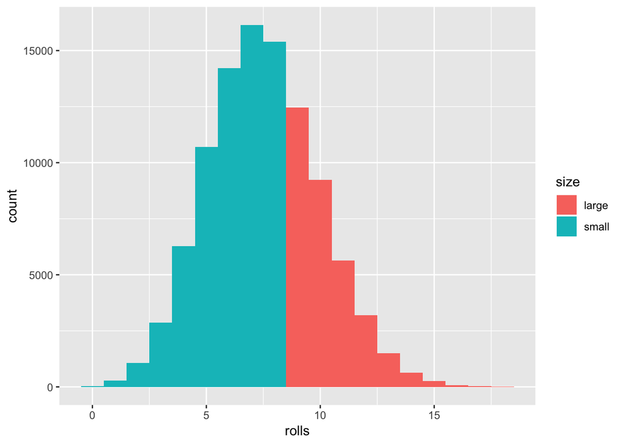

```r
screening<-15*0.6

data %>%
  mutate(size=if_else(rolls >= screening, "large", "small")) ->data


p <- ggplot(data, aes(x=rolls, fill = size)) +
  geom_histogram(binwidth = 1, position = "identity")
p
```

### 頻度

```r
pander(table(data$rolls))
```

Table continues below

| 0 | 1 | 2 | 3 | 4 | 5 | 6 | 7 | 8 | 9 | 10 |
| --- | --- | --- | --- | --- | --- | --- | --- | --- | --- | --- |
| 27 | 277 | 1068 | 2868 | 6286 | 10692 | 14210 | 16146 | 15400 | 12453 | 9235 |

| 11 | 12 | 13 | 14 | 15 | 16 | 17 | 18 |
| --- | --- | --- | --- | --- | --- | --- | --- |
| 5626 | 3203 | 1507 | 626 | 267 | 81 | 24 | 4 |

### 平均値と標準偏差

```r
mean(rolls) # 平均値
```

```
## [1] 7.49988
```

```r
sd(rolls) # 標準偏差
```

```
## [1] 2.454241
```

### 60%以上が男性である確率

```r
larges<-sum(data$size=="large")
smalls<-sum(data$size=="small")

larges/length(data$rolls)
```

```
## [1] 0.33026
```

### シミュレーションの時系列グラフ

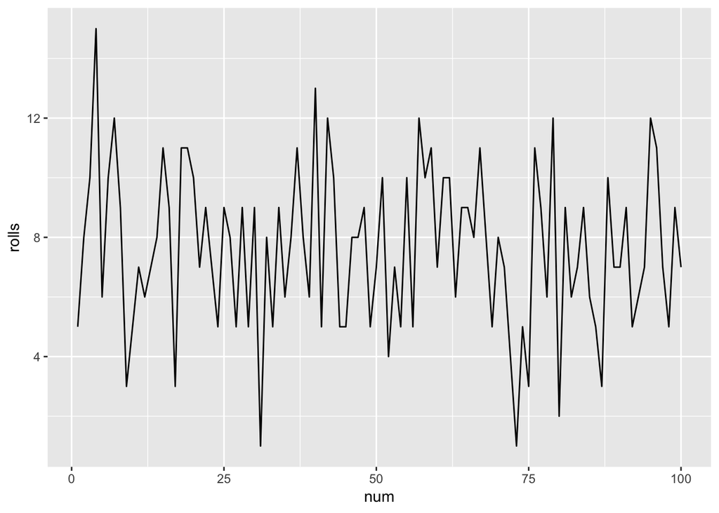

```r
data %>%
  mutate(num = row_number()) %>%
  filter(num <= 100) %>%
  ggplot(aes(x=num, y =rolls)) + geom_line()
```